# Unit 3 Assessment

Author

Ivan Cheng

Don’t forget to Load the Libraries:

# The Crooked Casino

A typical roulette wheel has 38 spaces (18 red spaces, 18 black, and 2 green). This particular casino has rigged the game so the probabilities are off. (What do you expect from a casino!)

The following table shows the probabilities for each color on the rigged roulette wheel. Use the table information to answer the following questions. (Run the code chunk to see it better)

```r
knitr::kable(tibble(' '="Probability", Red=.48, Black=.49, Green='???'))
```

|  | Red | Black | Green |
| --- | --- | --- | --- |
| Probability | 0.48 | 0.49 | ??? |

1. **QUESTION**: What is the probability of getting a green on the crooked wheel?  
   **ANSWER**: 0.03
2. **QUESTION**: Are you more or less likely to get a green on the crooked or a fair wheel?  
   **ANSWER**: Less

# Reasoning About the Mean

A bank manager keeps a record of the salaries of all her employees. One day, looking over the salaries, she noticed that John’s monthly salary was recorded as having an extra zero. It was supposed to be recorded as $5600 but was incorrectly recorded as $56,000. The average monthly salary of employees in this bank is $5900 with a standard deviation of $524.

3. **QUESTION**: How would correcting the error of John’s salary influence the mean?  
   **ANSWER**: The correct mean will be less than 5900
4. **QUESTION**: How would it influence the standard deviation?  
   **ANSWER**: The standard deviation will be less than 524

# Data Types

Indicate whether each of the following variables are quantitative or categorical:

5. **QUESTION**: A company’s profit in dollars each day:  
   **ANSWER**: quantitative
6. **QUESTION**: Whether or not a problem occurred in a day:  
   **ANSWER**: categorical
7. **QUESTION**: The shift of workers at a factory (day or night shift):  
   **ANSWER**: categorical
8. **QUESTION**: Miles driven since last oil change:  
   **ANSWER**: quantitative

# Interpreting Boxplots

Students in introductory statistics were presented with a page containing 30 colored rectangles. Their task was to name the colors as quickly as possible. Their times (in seconds) were recorded and categorized by gender. The boxplot of the times it took each gender to name all the colors are graphed below.

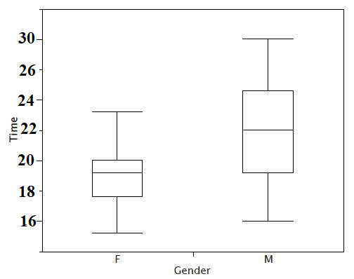

9. **QUESTION**: What is the approximate median time it took males to name all the colors?  
   **ANSWER**: 22 seconds
10. **QUESTION**: For the females, approximately what percent of them answered in less than 20 seconds?  
    **ANSWER**: 75%

# COVID-19 in NYC

A health science researcher from New York City wanted to see if those that had a problem with obesity were generally more vulnerable to severe COVID-19. He divided the state of New York into two groups, those that had a BMI in the obese range and those who did not. He then took a random sample of 50 people from each group and measured the number of COVID-19-related hospitalizations in each group.

11. **QUESTION**: What is the population of the study?  
    **ANSWER**: The people who have obesity
12. **QUESTION**: What is the sample of the study?  
    **ANSWER**: The 100 people randomly drawn from the 2 groups.
13. **QUESTION**: Which sampling method was used in the study above?  
    **ANSWER**: Simple Random Sampling
14. **QUESTION**: Is this study an observational study or an experiment?  
    **ANSWER**: observational study

# Reasoning about the Normal Distribution

In the graph below, two normal distributions are plotted, each with a different color.

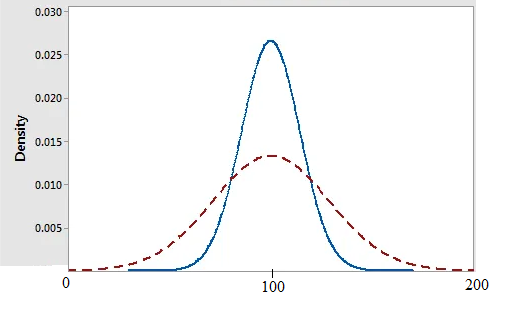

15. **QUESTION**: Which distribution appears to have the largest standard deviation, the dashed red line or the solid blue line?  
    **ANSWER**: dashed read line
16. **QUESTION**: Estimate the standard deviation of the red curve. (HINT: Think about how you would sketch out +/- 3 standard deviations)  
    **ANSWER**: 33

# Tennis Serves

During a tennis match, data were collected on the speed (in miles per hour) of the first and second serves. **Create a table of summary statistics** (including means, standard deviations, the 5 number summary and the sample size) for both serve types (First and Second).

```r
tennis <- import('https://github.com/byuistats/Math221D_Cannon/raw/master/Data/TennisServes.csv')
view(tennis$ServeSpeed_mph ~ tennis$ServeType)
favstats(tennis$ServeSpeed_mph ~ tennis$ServeType)
```

```
  tennis$ServeType min    Q1 median Q3 max mean       sd  n missing
1      First Serve  60 64.25   77.5 81  85 73.7 9.821179 10       0
2     Second Serve  59 65.25   71.5 79  85 71.8 9.040649 10       0
```

17. **QUESTION**: Which serve type is fastest based on the median?  
    **ANSWER**: First Serve
18. **QUESTION**: Compare the mean and the median for the *first* serve. What might this suggest about shape of the distribution of serve speeds of first serves?  
    **ANSWER**: Left Skewed

# Crossroads Purchases

A sample survey was taken of purchases at the Crossroads. Load the data into R:

```r
crossroads <- import('https://github.com/byuistats/Math221D_Cannon/raw/master/Data/CrossroadsPurchases.csv')
view(crossroads)
```

**Create a histogram** of purchase amounts.

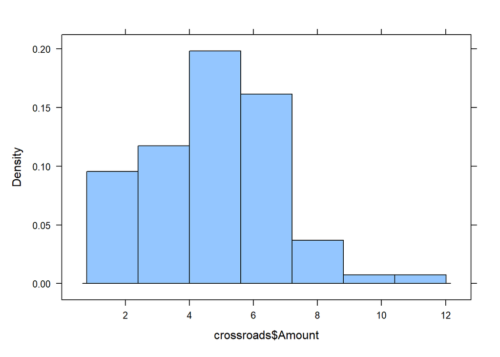

```r
histogram(crossroads$Amount)
```

**Create a QQPlot** of purchase amounts.

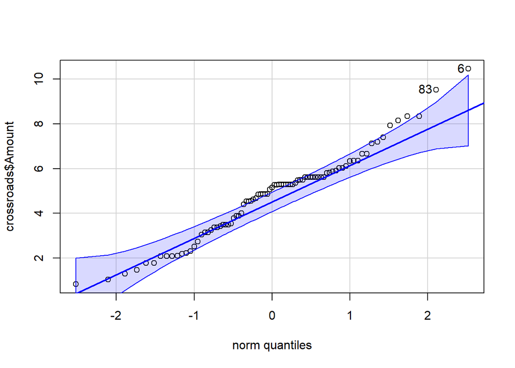

```
[1]  6 83
```

```r
qqPlot(crossroads$Amount) # Be careful for the spelling: "qqPlot" Uppercased P!
```

**Create a table of summary statistics** (including means, standard deviations, the 5 number summary and the sample size) of purchase amounts for all the payment methods.

```r
favstats(crossroads$Amount)
```

```
  min   Q1 median   Q3   max     mean       sd  n missing
 0.84 3.42   5.15 5.61 10.45 4.771059 1.911993 85       0
```

```r
favstats(crossroads$Amount ~ crossroads$Method)
```

```
  crossroads$Method  min     Q1 median     Q3   max     mean       sd  n
1              Cash 0.84 2.4400  4.545 5.4225  8.14 4.129167 1.950010 24
2            Credit 1.05 3.4200  5.290 6.3400 10.45 5.127931 2.313793 29
3            I-Card 1.79 4.2725  5.290 5.6100  7.93 4.929063 1.336090 32
  missing
1       0
2       0
3       0
```

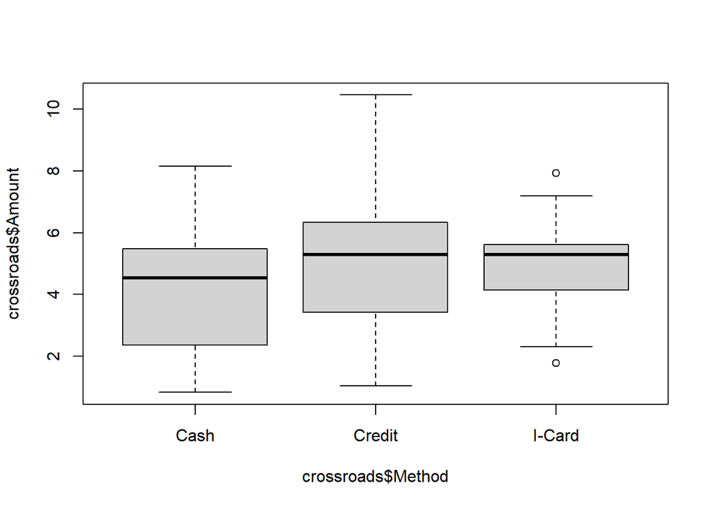

```r
boxplot(crossroads$Amount ~ crossroads$Method)
```

19. **QUESTION**: How would you describe the shape of the distribution based on the qqplot?  
    **ANSWER**: Symmetric distribution, very close to normal distribution
20. **QUESTION**: Which purchase method has the lowest first quartile (25th percentile)?  
    **ANSWER**: Cash
21. **QUESTION**: Which purchase method has the highest third quartile (75th percentile)?  
    **ANSWER**: Credit
22. **QUESTION**: What is the maximum purchase amount at the crossroads in this survey?  
    **ANSWER**: 10.45
23. **QUESTION**: Based on this sample, which payment method is the most frequently used?  
    **ANSWER**: I-Card
24. **QUESTION**: The results that you provided in the prior four questions, are they parameters or statistics, and why?  
    **ANSWER**: statistics. Since they are the data collected by the observational study, without applying different factors in it # -> !Review this question later!

# Climbing Gear

[figure not shown]

Carabiners are used for rock climbing and many construction jobs that require being tied to an anchor. Those who use carabiners depend on their strength and safety. A certain regulatory agency in the USA requires that a carabiner is capable of withstanding 3,600 pounds in all directions. A factory that produces carabiners wants test what percent of their equipment meets the regulatory requirements. Suppose the strength of the carabiners produced by the factory are normally distributed with average strength of 3,750 pounds and a standard deviation of 125 pounds.

```r
u = 3750
sd = 125

x_bar = 3600
n = 1

z = (x_bar - u) / sd / n
z
```

```
[1] -1.2
```

```r
pnorm(z)
```

```
[1] 0.1150697
```

```r
qnorm(0.99, u, sd)
```

```
[1] 4040.793
```

# GMAT

The admissions committees for most masters of business administration (MBA) programs require the Graduate Management Admission Test (GMAT) as part of the application for new students. It has been shown that the scores on the GMAT are normally distributed with a mean of 542.3 and a standard deviation of 120.54. (Source: MBA.com) The minimum GMAT score required for admission to the MAcc program in the School of Accountancy at BYU is 500, but it is rare for students with scores less than 600 to be admitted. (Source: Marriot school of Business-BYU)

31. **QUESTION**: What is the probability that a randomly selected student will score above 600 on the GMAT?  
    **ANSWER**: 0.3160834
32. **QUESTION**: What is the probability that a randomly selected student will score between 500 and 600 on the GMAT?  
    **ANSWER**: 0.3210927

Now consider a sample of size **n=15** students who took the GMAT.

33. **QUESTION**: What is the mean of the distribution of sample means?  
    **ANSWER**: 542.3
34. **QUESTION**: What is the standard deviation of the distribution of sample means?  
    **ANSWER**: 31.12329
35. **QUESTION**: What is the shape of the distribution of sample means?  
    **ANSWER**: Normal Distribution
36. **QUESTION**: What is the probability that a sample mean will be between 500 and 600?  
    **ANSWER**: 0.8810687
37. **QUESTION**: Define what a distribution of sample means is.  
    **ANSWER**: The distribution that is made of the sample means. In a more detailed way, each data in this distribution is the mean of certain samples.